# Lynx: shared warp on a century of trapping data

Hudson Bay lynx counts (~10-year booms) are the classic ecological cycle with **timing that drifts**. Here we:

1. Prefit **two** calendar sines (fast + slow structure in the series).
2. Learn **one shared warp** for both — peaks of both components shift together.
3. Replace the linear readout with small MLPs $f,g$: $\widehat{\mathrm{lynx}} = f(\mathrm{warp}(z_1)) + g(\mathrm{warp}(z_2))$.
4. Forecast the holdout and sample the **next boom's length**, not just its height.

Same dual loss as the synthetic notebook ($\lambda = 0.5$).

```python
import sys
from pathlib import Path
for _p in (Path.cwd().resolve().parents[1] / "src", Path.cwd().resolve().parent):
    s = str(_p)
    if _p.is_dir() and s not in sys.path:
        sys.path.insert(0, s)

%matplotlib inline
import matplotlib.pyplot as plt
import numpy as np

from utils import (
    plot_before_after_warp,
    plot_dual_objective_scatter,
    plot_fit_with_residual,
    plot_forecast_bands,
    plot_warp_offset,
    prepare_lynx_log,
    split_holdout,
)
from warp_regression import (
    interval_coverage,
    per_index_rw_sigma,
    prefit,
)
```

## Step 1: data and calendar prefit

Load annual counts and align two sines on calendar time. The holdout is the later years — never used in the fit below.

```python
data = prepare_lynx_log(transform="identity")
years, counts, t, y = data["years"], data["counts"], data["t"], data["y_log"]

split = split_holdout(years=data["years"], train_end_year=1910)
train_idx, test_idx = split["train_idx"], split["test_idx"]
years_tr, years_te = split["years_train"], split["years_test"]
y_tr, y_te = y[train_idx], y[test_idx]
t_tr = t[train_idx]
n_train = split["n_train"]

print(f"Train: {years_tr[0]}-{years_tr[-1]} (n={n_train})")
print(f"Test:  {years_te[0]}-{years_te[-1]} (n={split['n_test']})")

prefit_res = prefit(y_tr, t_tr, n_sines=2, years=years_tr)
fit = prefit_res.sine_fit
s1, s2 = fit["sine1"], fit["sine2"]
print(f"Sine 1: omega={s1['omega']:.3f}, period~{s1['period_years']:.1f} yr, a={s1['amplitude']:.3f}")
print(f"Sine 2: omega={s2['omega']:.3f}, period~{s2['period_years']:.1f} yr, peak_align={s2['peak_alignment']:.3f}")
print(f"Big peak years (train): {list(fit['big_peak_years'])}")
print(f"R²(train)={fit['r2_log']:.3f}")
```

```
Train: 1821-1910 (n=90)
Test:  1911-1934 (n=24)
Sine 1: omega=11.750, period~9.6 yr, a=1750.646
Sine 2: omega=2.958, period~38.2 yr, peak_align=0.491
Big peak years (train): [np.int32(1828), np.int32(1838), np.int32(1866), np.int32(1885), np.int32(1895), np.int32(1904)]
R²(train)=0.657
```

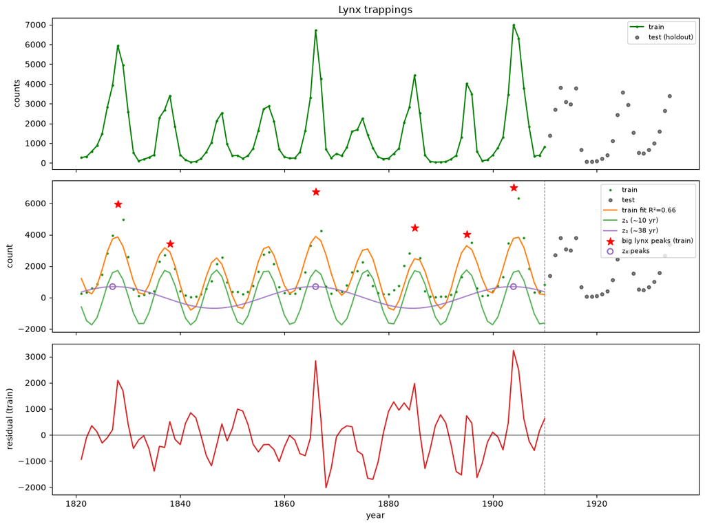

```python
fig, axes = plt.subplots(3, 1, figsize=(12, 9), sharex=True)

axes[0].plot(years_tr, counts[train_idx], "g.-", ms=4, label="train")
axes[0].plot(years_te, counts[test_idx], "ko", ms=4, alpha=0.5, label="test (holdout)")
axes[0].set_ylabel("counts")
axes[0].set_title("Lynx trappings")
axes[0].legend(fontsize=8)

plot_fit_with_residual(
    axes[1:], years_tr, y_tr, fit["y_hat_log"],
    x_test=years_te, y_test=y_te,
    train_label="train", test_label="test",
    fit_label=f"train fit R²={fit['r2_log']:.2f}",
    extra_lines=[
        (years_tr, fit["component1_log"], {"color": "C2", "alpha": 0.8, "label": f"z₁ (~{s1['period_years']:.0f} yr)"}),
        (years_tr, fit["component2_log"], {"color": "C4", "alpha": 0.8, "label": f"z₂ (~{s2['period_years']:.0f} yr)"}),
    ],
    extra_scatter=[
        (years_tr[fit["big_peak_idx"]], y_tr[fit["big_peak_idx"]], {"s": 90, "c": "red", "marker": "*", "zorder": 5, "label": "big lynx peaks (train)"}),
        (years_tr[fit["z2_peak_idx"]], fit["component2_log"][fit["z2_peak_idx"]], {"s": 45, "facecolors": "none", "edgecolors": "C4", "lw": 1.5, "label": "z₂ peaks"}),
    ],
    ylabel="count", residual_ylabel="residual (train)", xlabel="year",
    forecast_start_x=split["train_end_year"],
)
plt.tight_layout()
plt.show()
```

## Step 2: one shared warp, linear readout

Both sines share path knots $B$. A linear observation model is the baseline: does a single timing path explain both components?

```python
from warp_regression import WarpModel, soft_warp_numpy, DEFAULT_PATH_ANCHOR

z1 = prefit_res.covariates["z1"]
z2 = prefit_res.covariates["z2"]

# Separate linear WarpModel (transparent init for the MLP step).
linear = WarpModel.from_yaml(
    "lynx_linear.yaml",
    overrides={"train": {"epochs": 1500, "fit_lambda": 0.5, "seed": 0}},
)
fit_lin = linear.fit(
    y_tr, covariates={"z1": z1[:n_train], "z2": z2[:n_train]}, sine_fit=fit,
)
fit_w = {**fit, **fit_lin.fit}
fit_w["y_hat_log"] = fit_lin.y_hat
fit_w["r2_log"] = fit_lin.r2
fit_w["y_hat_log_unwarped"] = fit["y_hat_log"]
fit_w["r2_log_unwarped"] = fit["r2_log"]
p = fit_w["warp"]["p"]
fit_w["z1"] = z1[:n_train]
fit_w["z2"] = z2[:n_train]
fit_w["z1_warped"] = soft_warp_numpy(fit_w["z1"], p)
fit_w["z2_warped"] = soft_warp_numpy(fit_w["z2"], p)
B_init = linear.path_B()
w = fit_w["warp"]
print(f"Before warp (train): R²={fit_w['r2_log_unwarped']:.3f}")
print(
    f"After warp (train):  R²={fit_w['r2_log']:.3f}  "
    f"error NLL={w['obj_err']:.1f}  −terror={w['obj_time']:.1f}"
)
print(f"σ_t={w['sigma_t']:.3f}  σ_y={w['sigma_y']:.1f}  max|p−i|={w['max_abs_offset']:.2f}")
```

```
Before warp (train): R²=0.657
After warp (train):  R²=0.719  error NLL=737.0  −terror=0.2
σ_t=0.117  σ_y=871.2  max|p−i|=1.42
```

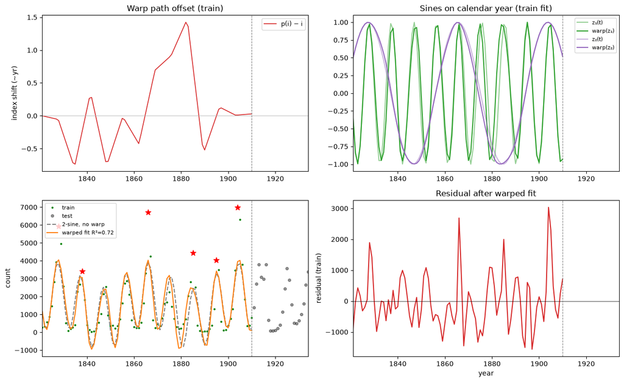

```python
idx_tr = np.arange(n_train)

fig, axes = plt.subplots(2, 2, figsize=(13, 8))

plot_warp_offset(axes[0, 0], years_tr, p, label="p(i) − i", title="Warp path offset (train)")
axes[0, 0].set_ylabel("index shift (~yr)")

axes[0, 1].plot(years_tr, fit_w["z1"], "C2", alpha=0.5, label="z₁(t)")
axes[0, 1].plot(years_tr, fit_w["z1_warped"], "C2", lw=1.5, label="warp(z₁)")
axes[0, 1].plot(years_tr, fit_w["z2"], "C4", alpha=0.5, label="z₂(t)")
axes[0, 1].plot(years_tr, fit_w["z2_warped"], "C4", lw=1.5, label="warp(z₂)")
axes[0, 1].set_title("Sines on calendar year (train fit)")
axes[0, 1].legend(fontsize=8)

axes[1, 0].plot(years_tr, y_tr, "g.", ms=4, label="train")
axes[1, 0].plot(years_te, y_te, "ko", ms=4, alpha=0.4, label="test")
axes[1, 0].plot(years_tr, fit_w["y_hat_log_unwarped"], "--", color="gray", label="2-sine, no warp")
axes[1, 0].plot(years_tr, fit_w["y_hat_log"], "C1", lw=1.5, label=f"warped fit R²={fit_w['r2_log']:.2f}")
axes[1, 0].scatter(years_tr[fit_w["big_peak_idx"]], y_tr[fit_w["big_peak_idx"]], s=70, c="red", marker="*", zorder=5)
axes[1, 0].set_ylabel("count")
axes[1, 0].legend(fontsize=8)

axes[1, 1].plot(years_tr, y_tr - fit_w["y_hat_log"], "C3")
axes[1, 1].axhline(0, color="k", lw=0.5)
axes[1, 1].set_ylabel("residual (train)")
axes[1, 1].set_xlabel("year")
axes[1, 1].set_title("Residual after warped fit")

for ax in axes.ravel():
    ax.axvline(split["train_end_year"], color="gray", ls="--", lw=0.8)
    ax.set_xlim(years[0], years[-1])

plt.tight_layout()
plt.show()
```

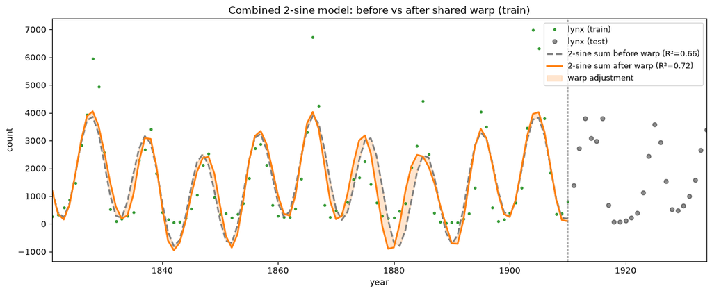

```python
fig, ax = plt.subplots(figsize=(12, 5))
plot_before_after_warp(
    ax, years_tr, y_tr, fit_w["y_hat_log_unwarped"], fit_w["y_hat_log"],
    x_test=years_te, y_test=y_te,
    r2_before=fit_w["r2_log_unwarped"], r2_after=fit_w["r2_log"],
    before_label="2-sine sum before warp", after_label="2-sine sum after warp",
    train_label="lynx (train)", test_label="lynx (test)",
    forecast_start_x=split["train_end_year"],
    ylabel="count", xlabel="year",
    title="Combined 2-sine model: before vs after shared warp (train)",
)
ax.set_xlim(years[0], years[-1])
plt.tight_layout()
plt.show()
```

## Step 3: nonlinear observation model

Replace the linear map with MLPs on each warped sine. Initialise path knots from the linear fit so training starts from a sensible warp, then refine under the same dual loss.

```python
from warp_regression import WarpModel

model = WarpModel.from_yaml(
    "lynx.yaml",
    overrides={"train": {"epochs": 2500, "fit_lambda": 0.5, "seed": 0}},
)
fit_res = model.fit(
    y_tr,
    covariates={"z1": z1[:n_train], "z2": z2[:n_train]},
    sine_fit=fit,
    B_init=B_init,
)
fit_nl = {**fit, **fit_res.fit}
fit_nl["y_hat_log"] = fit_res.y_hat
fit_nl["r2_log"] = fit_res.r2
fit_nl["y_hat_log_linear_warp"] = fit_w["y_hat_log"]
fit_nl["r2_log_linear_warp"] = fit_w["r2_log"]
fit_nl["r2_log_unwarped"] = fit["r2_log"]
fit_nl["y_hat_log_unwarped"] = fit["y_hat_log"]
p_nl = fit_nl["warp"]["p"]
print(
    f"unwarped f+g (train): R2={fit_nl['r2_log_unwarped']:.3f}  |  "
    f"linear warp: R2={fit_nl['r2_log_linear_warp']:.3f}  |  "
    f"f(warp)+g(warp): R2={fit_nl['r2_log']:.3f}"
)
print(f"Dual LL: obj_err={fit_nl['warp']['obj_err']:.1f}  obj_time={fit_nl['warp']['obj_time']:.1f}")
print(f"sigma_y={fit_nl['warp']['sigma_y']:.1f}  max |p-i| ~ {fit_nl['warp']['max_abs_offset']:.2f} yr")

# Cycle contributions from the MLP observation model
import torch
from warp_regression import soft_warp_numpy, DEFAULT_PATH_ANCHOR
z1w = soft_warp_numpy(z1[:n_train], p_nl)
z2w = soft_warp_numpy(z2[:n_train], p_nl)
obs = model.observation
with torch.no_grad():
    z1_t = torch.tensor(z1w, dtype=torch.float32)
    z2_t = torch.tensor(z2w, dtype=torch.float32)
    mlp_term = next(t for t in obs.terms if hasattr(t, "mlps"))
    mlps = list(mlp_term.mlps.values())
    fit_nl["component1_log"] = mlps[0](z1_t).numpy()
    fit_nl["component2_log"] = mlps[1](z2_t).numpy()
```

```
unwarped f+g (train): R2=0.657  |  linear warp: R2=0.719  |  f(warp)+g(warp): R2=0.985
Dual LL: obj_err=605.5  obj_time=0.5
sigma_y=203.9  max |p-i| ~ 1.49 yr
```

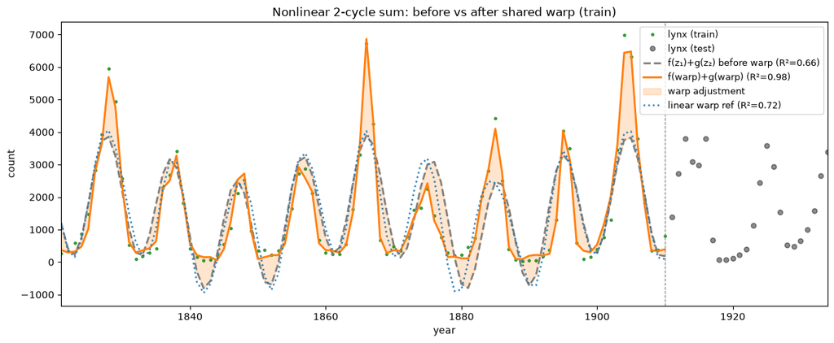

```python
fig, ax = plt.subplots(figsize=(12, 5))
plot_before_after_warp(
    ax, years_tr, y_tr, fit_nl["y_hat_log_unwarped"], fit_nl["y_hat_log"],
    x_test=years_te, y_test=y_te,
    r2_before=fit_nl["r2_log_unwarped"], r2_after=fit_nl["r2_log"],
    before_label="f(z₁)+g(z₂) before warp", after_label="f(warp)+g(warp)",
    train_label="lynx (train)", test_label="lynx (test)",
    extra_lines=[(years_tr, fit_nl["y_hat_log_linear_warp"], {"color": "C0", "ls": ":", "lw": 1.8, "alpha": 0.9, "label": f"linear warp ref (R²={fit_nl['r2_log_linear_warp']:.2f})"})],
    forecast_start_x=split["train_end_year"],
    ylabel="count", xlabel="year",
    title="Nonlinear 2-cycle sum: before vs after shared warp (train)",
)
ax.set_xlim(years[0], years[-1])
plt.tight_layout()
plt.show()
```

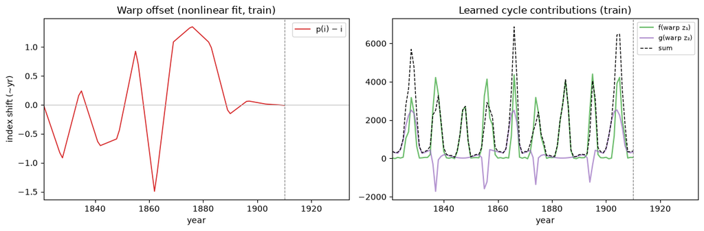

```python
fig, axes = plt.subplots(1, 2, figsize=(12, 4))
plot_warp_offset(axes[0], years_tr, p_nl, label="p(i) − i", title="Warp offset (nonlinear fit, train)")
axes[0].set_ylabel("index shift (~yr)")
axes[1].plot(years_tr, fit_nl["component1_log"], "C2", alpha=0.7, label="f(warp z₁)")
axes[1].plot(years_tr, fit_nl["component2_log"], "C4", alpha=0.7, label="g(warp z₂)")
axes[1].plot(years_tr, fit_nl["y_hat_log"], "k--", lw=1, label="sum")
axes[1].set_title("Learned cycle contributions (train)")
axes[1].legend(fontsize=8)
for ax in axes:
    ax.axvline(split["train_end_year"], color="gray", ls="--", lw=0.8)
    ax.set_xlim(years[0], years[-1])
    ax.set_xlabel("year")
plt.tight_layout()
plt.show()
```

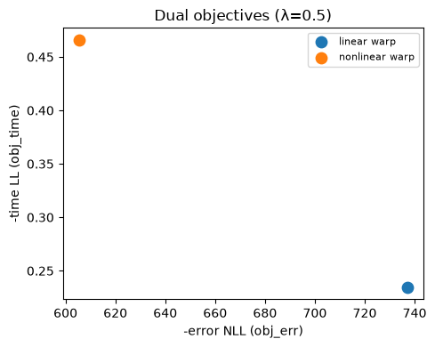

```python
fig, ax = plt.subplots(figsize=(5, 4))
plot_dual_objective_scatter(
    ax,
    [
        {"x": fit_w["warp"]["obj_err"], "y": fit_w["warp"]["obj_time"], "label": "linear warp"},
        {"x": fit_nl["warp"]["obj_err"], "y": fit_nl["warp"]["obj_time"], "label": "nonlinear warp"},
    ],
    title="Dual objectives (λ=0.5)",
)
plt.tight_layout()
plt.show()
```